# Exploring 3D Sinusoidal Data using Artificial Neural Networks

## Overview

Using artificial neural networks to solve simple regression problems. A `Sequential` model of the neural network was created and fitted to a noisy 3D sinusoidal data set. Hyperparameter values were manually adjusted and the influences they have on the model's predictions were observed. The hyperparameter space were manually sweeped to try to hone in on the reasonable hyperparameter values.

## Preliminaries

```python
#===============
# COMMON IMPORTS
#===============
import matplotlib.pyplot as plt
import matplotlib as mpl
from matplotlib import cm
import numpy as np
import pandas as pd
%matplotlib inline
mpl.rc('axes', labelsize=14)
mpl.rc('xtick', labelsize=12)
mpl.rc('ytick', labelsize=12)
import os

#=================================
# WHERE TO SAVE THE FIGURES METHOD
#=================================
PROJECT_ROOT_DIR = "."
FOLDER = "figures"
IMAGES_PATH = os.path.join(PROJECT_ROOT_DIR, FOLDER)
os.makedirs(IMAGES_PATH, exist_ok=True)
def save_fig(fig_id, tight_layout=True, fig_extension="png", resolution=300):
    path = os.path.join(IMAGES_PATH, fig_id + "." + fig_extension)
    print("Saving figure", fig_id)
    if tight_layout:
        plt.tight_layout()
    plt.savefig(path, format=fig_extension, dpi=resolution)
```

```python
#===================================
# PLOT 3D SCATTER DATA POINTS METHOD
#===================================
def plot3Ddata(data_df):

    #=======
    #IMPORTS
    #=======
    from mpl_toolkits.mplot3d import Axes3D
    import matplotlib.pyplot as plt

    #========
    #DATASETS
    #========
    xdata = data_df["x"]
    ydata = data_df["y"]
    zdata = data_df["z"]

    #==============
    #SIZE OF A PLOT
    #==============
    fig = plt.figure(figsize = [17.50, 15.00])


    #=========================
    #FIRST SCATTERPLOT SUBPLOT
    #=========================
    #SET UP THE AXES
    ax1 = fig.add_subplot(2, 2, 1, projection = '3d')                                #ROW 1, COLUMN 1 IN 2 ROWS 2 COLUMNS
    ax1.set_xlim(-1.6, 1.6)
    ax1.set_ylim(-1.6, 1.6)
    ax1.set_zlim(-1.6, 1.6)
    #3D PLOTTING OF SCATTER DATAPOINTS
    ax1.scatter3D(xdata, ydata, zdata, c=zdata, cmap='GnBu', vmin=-2.0, vmax=0.4);   #CMAP, COLOR MAP, FOR DATAPOINTS
    #CHANGE DEFAULT VIEW ANGLE USING view_init() METHOD.
    #1ST PARAMETER IS ELEVATION ABOVE x - y PLANE.
    #2ND PARAMETER IS ROTATION COUNTER CLOCKWISE ABOUT z-AXIS
    ax1.view_init(0, 90)

    #==========================
    #SECOND SCATTERPLOT SUBPLOT
    #==========================
    #SET UP THE AXES
    ax2 = fig.add_subplot(2, 2, 2, projection = '3d')                                #ROW 1, COLUMN 2 IN 2 ROWS 2 COLUMNS
    ax2.set_xlim(-1.6, 1.6)
    ax2.set_ylim(-1.6, 1.6)
    ax2.set_zlim(-1.6, 1.6)
    #3D PLOTTING OF SCATTER DATAPOINTS
    ax2.scatter3D(xdata, ydata, zdata, c=zdata, cmap='GnBu', vmin=-2.0, vmax=0.4);   #CMAP, COLOR MAP, FOR DATAPOINTS
    #CHANGE DEFAULT VIEW ANGLE USING view_init() METHOD.
    #1ST PARAMETER IS ELEVATION ABOVE x - y PLANE.
    #2ND PARAMETER IS ROTATION COUNTER CLOCKWISE ABOUT z-AXIS
    ax2.view_init(25,0)

    #=========================
    #THIRD SCATTERPLOT SUBPLOT
    #=========================
    #SET UP THE AXES
    ax3 = fig.add_subplot(2, 2, 3, projection = '3d')                                #ROW 2, COLUMN 1 IN 2 ROWS 2 COLUMNS
    ax3.set_xlim(-1.6, 1.6)
    ax3.set_ylim(-1.6, 1.6)
    ax3.set_zlim(-1.6, 1.6)
    #3D PLOTTING OF SCATTER DATAPOINTS
    ax3.scatter3D(xdata, ydata, zdata, c=zdata, cmap='GnBu', vmin=-2.0, vmax=0.4);   #CMAP, COLOR MAP, FOR DATAPOINTS
    #CHANGE DEFAULT VIEW ANGLE USING view_init() METHOD.
    #1ST PARAMETER IS ELEVATION ABOVE x - y PLANE.
    #2ND PARAMETER IS ROTATION COUNTER CLOCKWISE ABOUT z-AXIS
    ax3.view_init(25, 90)

    #==========================
    #FOURTH SCATTERPLOT SUBPLOT
    #==========================
    #SET UP THE AXES
    ax4 = fig.add_subplot(2, 2, 4, projection = '3d')                                #ROW 2, COLUMN 2 IN 2 ROWS 2 COLUMNS
    ax4.set_xlim(-1.6, 1.6)
    ax4.set_ylim(-1.6, 1.6)
    ax4.set_zlim(-1.6, 1.6)
    #3D PLOTTING OF SCATTER DATAPOINTS
    ax4.scatter3D(xdata, ydata, zdata, c=zdata, cmap='GnBu', vmin=-2.0, vmax=0.4);   #CMAP, COLOR MAP, FOR DATAPOINTS
    #CHANGE DEFAULT VIEW ANGLE USING view_init() METHOD.
    #1ST PARAMETER IS ELEVATION ABOVE x - y PLANE.
    #2ND PARAMETER IS ROTATION COUNTER CLOCKWISE ABOUT z-AXIS
    ax4.view_init(90,90)

    #===============
    #SET AXIS LABELS
    #===============
    ax1.set_xlabel('x')
    ax1.set_ylabel('y')
    ax1.set_zlabel('z')

    ax2.set_xlabel('x')
    ax2.set_ylabel('y')
    ax2.set_zlabel('z')

    ax3.set_xlabel('x')
    ax3.set_ylabel('y')
    ax3.set_zlabel('z')

    ax4.set_xlabel('x')
    ax4.set_ylabel('y')
    ax4.set_zlabel('z')

    #=========
    #SHOW PLOT
    #=========
    plt.show()
```

```python
#==============================================================
# PLOT THE 3D SCATTERED DATA POINTS AND THE 3D PREDICTIVE CURVE
#==============================================================

def plotscatter3Ddata(fit_x, fit_y, fit_z, scat_x, scat_y, scat_z):
#Numpy arrays fit_x and fit_y represent the x and y coordinates from the training data and
#fit_z represents the model predictions from those coordinates (i.e. the prediction curve).
#The three Numpy arrays called `scat_x, scat_y,` and  `scat_z` represent the x, y, and
#z coordinates of the training data.

    from mpl_toolkits import mplot3d
    import numpy as np
    import matplotlib.pyplot as plt

    #=======================
    #DATA FOR SCATTER POINTS
    #=======================
    xdata = scat_x
    ydata = scat_y
    zdata = scat_z

    #============================
    #DATA FOR 3D PREDICTIVE CURVE
    #============================
    xfit = fit_x
    yfit = fit_y
    zfit = fit_z

    #==============
    #SIZE OF A PLOT
    #==============
    fig = plt.figure(figsize = [15, 15])

    #=========================
    #FIRST SCATTERPLOT SUBPLOT
    #=========================
    #SET UP THE AXES
    ax1 = fig.add_subplot(2, 2, 1, projection = '3d')                                #ROW 1, COLUMN 1 IN 2 ROWS 2 COLUMNS
    ax1.set_xlim(-1.6, 1.6)
    ax1.set_ylim(-1.6, 1.6)
    ax1.set_zlim(-1.6, 1.6)
    #3D PLOTTING OF SCATTER DATAPOINTS
    ax1.scatter3D(xdata, ydata, zdata, c=ydata, cmap='GnBu', vmin=-2.0, vmax=0.4);   #CMAP, COLOR MAP, FOR DATAPOINTS
    ax1.plot3D(xfit, yfit, zfit, 'black')
    #CHANGE DEFAULT VIEW ANGLE USING view_init() METHOD.
    #1ST PARAMETER IS ELEVATION ABOVE x - y PLANE.
    #2ND PARAMETER IS ROTATION COUNTER CLOCKWISE ABOUT z-AXIS
    ax1.view_init(0, 90)

    #==========================
    #SECOND SCATTERPLOT SUBPLOT
    #==========================
    #SET UP THE AXES
    ax2 = fig.add_subplot(2, 2, 2, projection = '3d')                                #ROW 1, COLUMN 2 IN 2 ROWS 2 COLUMNS
    ax2.set_xlim(-1.6, 1.6)
    ax2.set_ylim(-1.6, 1.6)
    ax2.set_zlim(-1.6, 1.6)
    #3D PLOTTING OF SCATTER DATAPOINTS
    ax2.scatter3D(xdata, ydata, zdata, c=ydata, cmap='GnBu', vmin=-2.0, vmax=0.4);   #CMAP, COLOR MAP, FOR DATAPOINTS
    ax2.plot3D(xfit, yfit, zfit, 'black')
    #CHANGE DEFAULT VIEW ANGLE USING view_init() METHOD.
    #1ST PARAMETER IS ELEVATION ABOVE x - y PLANE.
    #2ND PARAMETER IS ROTATION COUNTER CLOCKWISE ABOUT z-AXIS
    ax2.view_init(25,0)

    #=========================
    #THIRD SCATTERPLOT SUBPLOT
    #=========================
    #SET UP THE AXES
    ax3 = fig.add_subplot(2, 2, 3, projection = '3d')                                #ROW 2, COLUMN 1 IN 2 ROWS 2 COLUMNS
    ax3.set_xlim(-1.6, 1.6)
    ax3.set_ylim(-1.6, 1.6)
    ax3.set_zlim(-1.6, 1.6)
    #3D PLOTTING OF SCATTER DATAPOINTS
    ax3.scatter3D(xdata, ydata, zdata, c=ydata, cmap='GnBu', vmin=-2.0, vmax=0.4);   #CMAP, COLOR MAP, FOR DATAPOINTS
    ax3.plot3D(xfit, yfit, zfit, 'black')
    #CHANGE DEFAULT VIEW ANGLE USING view_init() METHOD.
    #1ST PARAMETER IS ELEVATION ABOVE x - y PLANE.
    #2ND PARAMETER IS ROTATION COUNTER CLOCKWISE ABOUT z-AXIS
    ax3.view_init(25, 90)

    #==========================
    #FOURTH SCATTERPLOT SUBPLOT
    #==========================
    #SET UP THE AXES
    ax4 = fig.add_subplot(2, 2, 4, projection = '3d')                                #ROW 2, COLUMN 2 IN 2 ROWS 2 COLUMNS
    ax4.set_xlim(-1.6, 1.6)
    ax4.set_ylim(-1.6, 1.6)
    ax4.set_zlim(-1.6, 1.6)
    #3D PLOTTING OF SCATTER DATAPOINTS
    ax4.scatter3D(xdata, ydata, zdata, c=ydata, cmap='GnBu', vmin=-2.0, vmax=0.4);   #CMAP, COLOR MAP, FOR DATAPOINTS
    ax4.plot3D(xfit, yfit, zfit, 'black')
    #CHANGE DEFAULT VIEW ANGLE USING view_init() METHOD.
    #1ST PARAMETER IS ELEVATION ABOVE x - y PLANE.
    #2ND PARAMETER IS ROTATION COUNTER CLOCKWISE ABOUT z-AXIS
    ax4.view_init(90,90)

    #===============
    #SET AXIS LABELS
    #===============
    ax1.set_xlabel('x')
    ax1.set_ylabel('y')
    ax1.set_zlabel('z')

    ax2.set_xlabel('x')
    ax2.set_ylabel('y')
    ax2.set_zlabel('z')

    ax3.set_xlabel('x')
    ax3.set_ylabel('y')
    ax3.set_zlabel('z')

    ax4.set_xlabel('x')
    ax4.set_ylabel('y')
    ax4.set_zlabel('z')

    #=========
    #SHOW PLOT
    #=========
    plt.show()
```

# Importing, Splitting, and Standardizing 3D Sinusoidal Data

```python
#===========
#IMPORT DATA
#===========

import pandas as pd

data = pd.read_csv('3DSinusoidalANN.csv')

#=========================================
#SPLIT DATA INTO TRAINING AND TESTING DATA
#=========================================

from sklearn.model_selection import train_test_split

#Returned columns 'x' and 'y' as feature matrix called 'X'
X = data[['x', 'z']]

#Returned column 'z' as labels called 'y'
y = data[['y']]

#Split data with test size of 20% and random state of 42. Returned as dataframes
X_train, X_test, y_train, y_test = train_test_split(X, y, test_size = 0.2, random_state = 42)
```

```python
#===================================
#NORMALIZE TRAINING AND TESTING DATA
#===================================

from sklearn.preprocessing import MinMaxScaler
scaler = MinMaxScaler(feature_range=(-1.5, 1.5))

X_train_n = scaler.fit_transform(X_train)
X_train_n = pd.DataFrame(X_train_n, columns=['x','z'])

y_train_n = scaler.fit_transform(y_train)
y_train_n = pd.DataFrame(y_train_n, columns=['y'])

X_test_n = scaler.fit_transform(X_test)
y_test_n = scaler.fit_transform(y_test)
```

# Plotting of Raw 3D Sinusoidal Data

Plot raw training data by calling the plot3Ddata method, which accepts a Pandas DataFrame (composed of 3 spatial coordinates) and uses scatter3D() to plot the data. The test set are not used here. They're used for calculating the generalization error. The graph have four subplots.

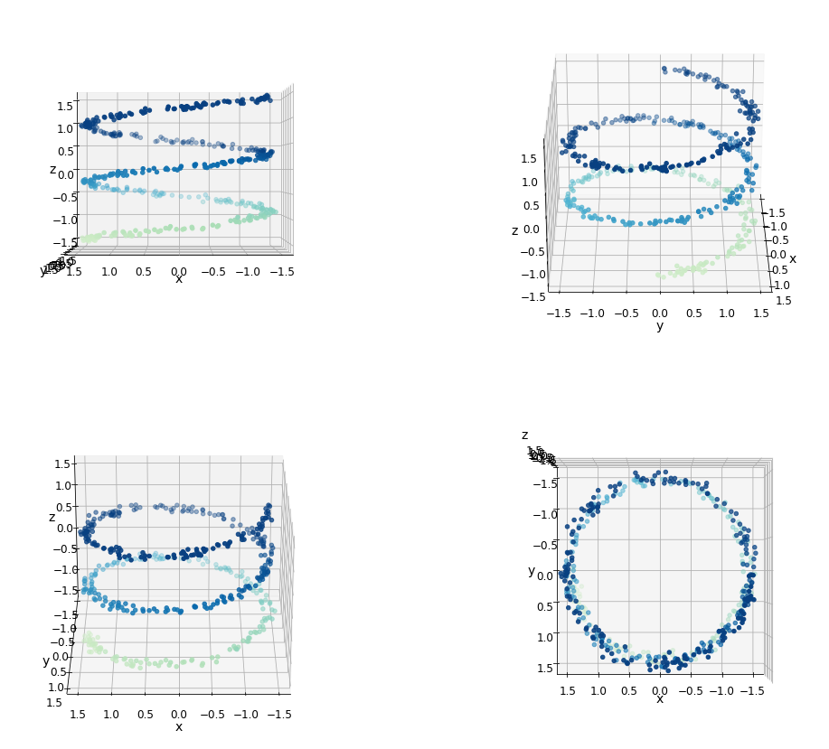

```python
#=============================================================
#PLOT 3D SCATTERPLOTS OF RAW TRAINING DATA X_train and y_train
#=============================================================

#Joining feature dataframes and label dataframe side by side specified by concat method with axis=1 and join='inner'
X_y_train_n_df = pd.concat([X_train_n, y_train_n], axis=1, join='inner')

#Pass dataframe composed of X_train and y_train to plot3Ddata() method for 3D plotting of the training data
plot3Ddata(X_y_train_n_df)
```

# Exploring 3D Sinusoidal Data with Artifical Neural Networks

### Creating and fitting a `Sequential` model to the 3D sinusoidal data.

Manually assigning and adjusting a combination of hyperparameter values, including the number of nuerons per layer and the number of layers, until there is an optimal combination of hyperparameter values for the `Sequential` model.

```python
#==========================================================================
#CREATE SEQUENTIAL MODEL WITH LAYERS FOR REGRESSION WITH 3D SINUSOIDAL DATA
#==========================================================================

import keras
from keras.models import Sequential
from keras.layers import Dense

#Create sequential model with layers
model = Sequential()
model.add(Dense(500, input_dim=2, activation= "relu"))
model.add(Dense(100, activation= "relu"))
model.add(Dense(50, activation= "relu"))
model.add(Dense(1))

model.summary()
```

```
Model: "sequential"
_________________________________________________________________
 Layer (type)                Output Shape              Param #
=================================================================
 dense (Dense)               (None, 500)               1500

 dense_1 (Dense)             (None, 100)               50100

 dense_2 (Dense)             (None, 50)                5050

 dense_3 (Dense)             (None, 1)                 51

=================================================================
Total params: 56,701
Trainable params: 56,701
Non-trainable params: 0
_________________________________________________________________
```

```python
#====================================
#COMPILE SEQUENTIAL MODEL WITH LAYERS
#====================================
model.compile(loss="mean_squared_error", optimizer="adam", metrics=["mean_squared_error"])

#======================================
#FIT/TRAIN SEQUENTIAL MODEL WITH LAYERS
#======================================
model.fit(X_train_n, y_train_n, epochs=80)
```

```
<keras.callbacks.History at 0x1f756a7cb50>
```

```python
#==============================================================
#PREDICTIONS ON TRAINING SET USING SEQUENTIAL MODEL WITH LAYERS
#==============================================================

#Predictions on training feature data using sequential model with layers
fit_y = model.predict(X_train_n)
```

```python
#=================================================
#MEASURING MSE OF THE SEQUENTIAL MODEL WITH LAYERS
#=================================================

from sklearn.metrics import mean_squared_error

print(np.sqrt(mean_squared_error(y_train_n,fit_y)))
```

```
0.18170259635095218
```

### Plotting Model Predictions for Training Set

Predictions were made for `y` using the `x` and `z` training data. The `plotscatter3Ddata(fit_x, fit_y, fit_z, scat_x, scat_y, scat_z)` function were used to plot the data and the prediction curve.

```python
#===================================================================
#SPLIT UP TRAINING DATAFRAME (x,y,z) INTO SEPARATED x, y, AND z DATA
#===================================================================

#Convert dataframe to numpy array
scat_x = np.array(X_y_train_n_df['x'])
scat_y = np.array(X_y_train_n_df['y'])
scat_z = np.array(X_y_train_n_df['z'])
```

```python
#====================================================================================
#CONCATENATING TRAINING FEATURE x and z DATAFRAMES WITH PREDICTIONS DATAFRAME (fit_y)
#====================================================================================

#CONVERT NUMPY ARRAY TO DATAFRAME
fit_x_sorted = pd.DataFrame(scat_x, columns=["x"])      # Feature data
fit_y_sorted = pd.DataFrame(fit_y, columns=["y"])       # Predicted data
fit_z_sorted = pd.DataFrame(scat_z, columns=["z"])      # Feature data

#CREATE DATAFRAME OF CONCATENATED FEATURE DATAFRAMES AND PREDICTED DATAFRAME SIDE BY SIDE
#Specified by concat method with axis=1 and join='inner'
fit_xyz_sorted_df = pd.concat([fit_x_sorted, fit_y_sorted, fit_z_sorted], axis=1, join='inner')


#========================================================================================================
#IN PREPARATION OF PLOTTING PREDICTIVE CURVE, DETERMINED BY PREDICTIONS fit_y, THE CONCATENATED DATAFRAME
#CONTAINING THE FEATURE DATA AND PREDICTED DATA WERE SORTED BY FEATURE 'z' IN DESCENDING ORDER. THIS
#RESULTS IN A NON MESSY PLOTTING.
#========================================================================================================
fit_xyz_sorted_df = fit_xyz_sorted_df.sort_values(by=['z'], ascending=False)



#=================================
#SPLITTING UP THE SORTED DATAFRAME
#=================================
#AFTER SORTING, SPLITTING INTO SEPARATE FEATURES x AND z DATA AND INTO A SEPARATED PREDICTED y DATA
#Then convert dataframe to numpy array
fit_x = np.array(fit_xyz_sorted_df['x'])               # Feature data
fit_y = np.array(fit_xyz_sorted_df['y'])               # Feature data
fit_z = np.array(fit_xyz_sorted_df['z'])               # Predicted data
```

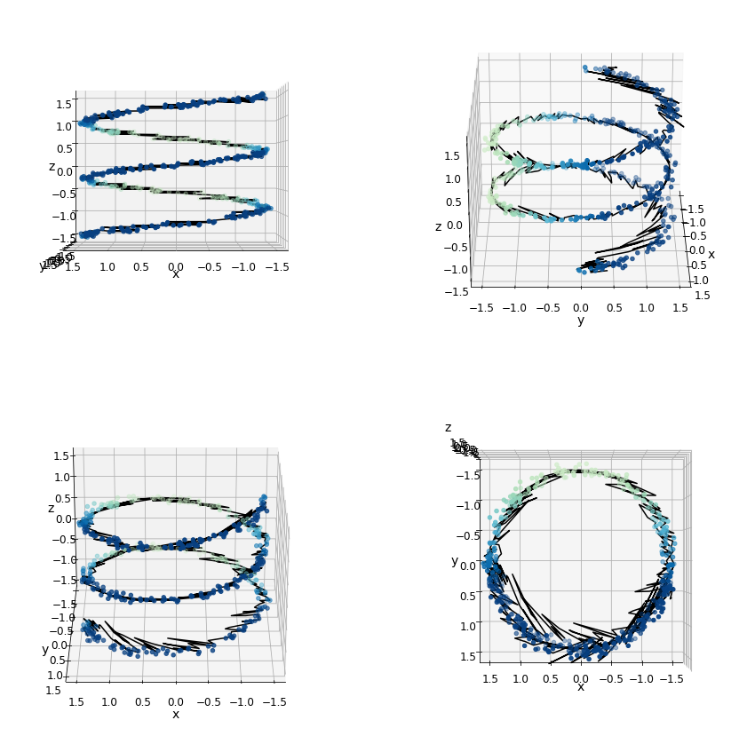

```python
#=====================================
#PLOT PREDICTIVE CURVE ON TRAINING SET
#=====================================

plotscatter3Ddata(fit_x, fit_y, fit_z, scat_x, scat_y, scat_z)
```

# Computing the Generalization Error

Using MSE as the Generalization Error Metric

```python
#=======================================================================
#GENERALIZATION ERROR FOR SEQUENTIAL MODEL USING MSE, MEAN SQUARED ERROR
#=======================================================================

from sklearn.metrics import mean_squared_error

# True y-labels
y_true = y_test_n

#Predictions on a test dataset using Sequential model
y_preds = model.predict(X_test_n)

#MSE for Sequential model, using true y-labels and predictions
MSE_SequentialModel = mean_squared_error(y_true, y_preds)

#Answer rounded to four significant digits
MSE_SequentialModel = round(MSE_SequentialModel, 3)


#Display MSE
print("MSE for Sequential model of the Artificial Neural Network: ", MSE_SequentialModel)
```

```
MSE for Sequential model of the Artificial Neural Network:  0.041
```